# Twitter Analysis - Darren Abbruzzese

S.Mckinnon

Jan 2017

### *Synopsis*

This is an Text Analysis of [Darren Abbruzzese](https://twitter.com/search?src=typd&q=abbruzzd&lang=en) twitter account activity covering the period Nov 2016 - Jan 2017 using [Rmarkdown](http://rmarkdown.rstudio.com/).

It investigates activity, what has been popular within the community, a sentiment analysis of content and finally a facial expression analysis.

While some interesting points are uncovered it should noted that the current data set is probably to limited to draw any strong conclusions.

### *Background*

From: Abbruzzese, Darren  
Sent: Tuesday, 8 November 2016 12:09 PM  
To: “Technology Data - All Subject: Speedy comms - CIO changes

Hi team,

I’ve been getting into [Twitter](https://twitter.com/search?src=typd&q=%40abbruzzd&lang=en) lately…I re-tweet stuff I find interesting which you can check out [‘@abbruzzd’](https://twitter.com/search?src=typd&q=abbruzzd&lang=en)…. It’s a trial .. we’ll see how it goes."

*OK…* I had been studying [R](https://www.coursera.org/specializations/jhu-data-science) for a while, this looked like a good opportunity for a practical case study.

### *Packages Used*

To do the Data wrangling we have a few key packages; [Stringr](https://cran.r-project.org/web/packages/stringr/vignettes/stringr.html), [reshape2](https://cran.r-project.org/web/packages/reshape2/reshape2.pdf) & [dplyr](https://cran.rstudio.com/web/packages/dplyr/vignettes/introduction.html). We are also dealing with dates/time stamps so [lubridate](https://cran.r-project.org/web/packages/lubridate/lubridate.pdf) will also help.

To Graph the data [ggplot2](http://ggplot2.org/) & [RColorBrewer](https://cran.r-project.org/web/packages/RColorBrewer/RColorBrewer.pdf) will be key. I will also be using [pander](http://rapporter.github.io/pander/) to help with some of the table formatting in this document.

To complete the Text and Sentiment analysis [tidytext](https://cran.r-project.org/web/packages/tidytext/vignettes/tidytext.html) and [wordcloud](https://cran.r-project.org/web/packages/wordcloud/wordcloud.pdf) is used.

```r
library(stringr)
library(dplyr)
library(ggplot2)
library(lubridate)
library(reshape2)
library(tidytext)
library(RColorBrewer)
library(wordcloud)
library(pander)
```

#### *Key Points*

There are a couple of house keeping items before we begin:

- The R Twitter [API](https://cran.r-project.org/web/packages/twitteR/twitteR.pdf) has restrictions on both [volume](https://dev.twitter.com/rest/public/rate-limiting) and [history](https://support.twitter.com/articles/15364).
- [Twitter](https://www.lifewire.com/what-exactly-is-twitter-2483331) is reliant on what people type. This includes spelling mistakes, mis-typed [hashtages](https://support.twitter.com/articles/49309) and incorrect locations, etc… This analysis is limited by as such [carbon errors](https://en.wikipedia.org/wiki/User_error).
- These stats change on a daily basis. Different days will get different results.

### *Data Processing*

Thanks to Twitter-API [restrictions](https://support.twitter.com/articles/15364), the first step was to create a Twitter scrapper which could be run, building up the history required for an analysis.

For this I re-use the process described [here](https://www.r-bloggers.com/how-to-use-r-to-scrape-tweets-super-tuesday-2016/). This required a a Twitter account and then creating an app within the [development platform](https://dev.twitter.com/) to enable scrapping of data.

```r
#load the packages required to connect to Twitter
library(twitteR)
library(ROAuth)
# from your DEV App you will get connection configs
api_key <- "replace with your API key"
api_secret <- "replace with your API secret"
token <- "replace with your Token key"
token_secret <- "replace with your token secret"

# Create Twitter Connection
setup_twitter_oauth(api_key, api_secret, token, token_secret)

# once you have a successful connection
# return all tweets were @abbruzzd is mentioned
tweets <- searchTwitter("@abbruzzd", lang="en", since="2014-12-01")
# transform into a standard data frame for R
tweets_df <- twListToDF(tweets)
# return the tweets that appear on @abbruzzd's time line
tweets_UT=userTimeline('@abbruzzd')
# transform into a standard data frame for R
tweets_UT_df <- twListToDF(tweets_UT)

# create a date reference for the file name
nam1 <- paste0("tweets_time", substr(date(),0,10))
nam2 <- paste0("tweets_men", substr(date(),0,10))

# save each data frame as a text file locally
write.table(tweets_UT_df, file=paste0("./", nam1, ".txt"), sep=",", row.names = FALSE)
write.table(tweets_df, file=paste0("./", nam2, ".txt"), sep=",", row.names = FALSE)
```

The Key part of this process is the following message;

*setup_twitter_oauth(api_key, api_secret, token, token_secret)*  
**[1] “Using direct authentication”**

This message lets you know you have successfully connected to [Twitter’s API](https://dev.twitter.com/docs)

For obvious reasons, this analysis will just load from files created by this scrapper.

### *Analyzing the Content*

The main issue is the sparsity of the the data, Darren just isn’t very activity on twitter.

```
---------------------------------------------------------
Since 2016-11-01 11:12:30 @abbruzzd has tweeted 58 times.

---------------------------------------------------------
```

Let have a look at the frequency of activity.

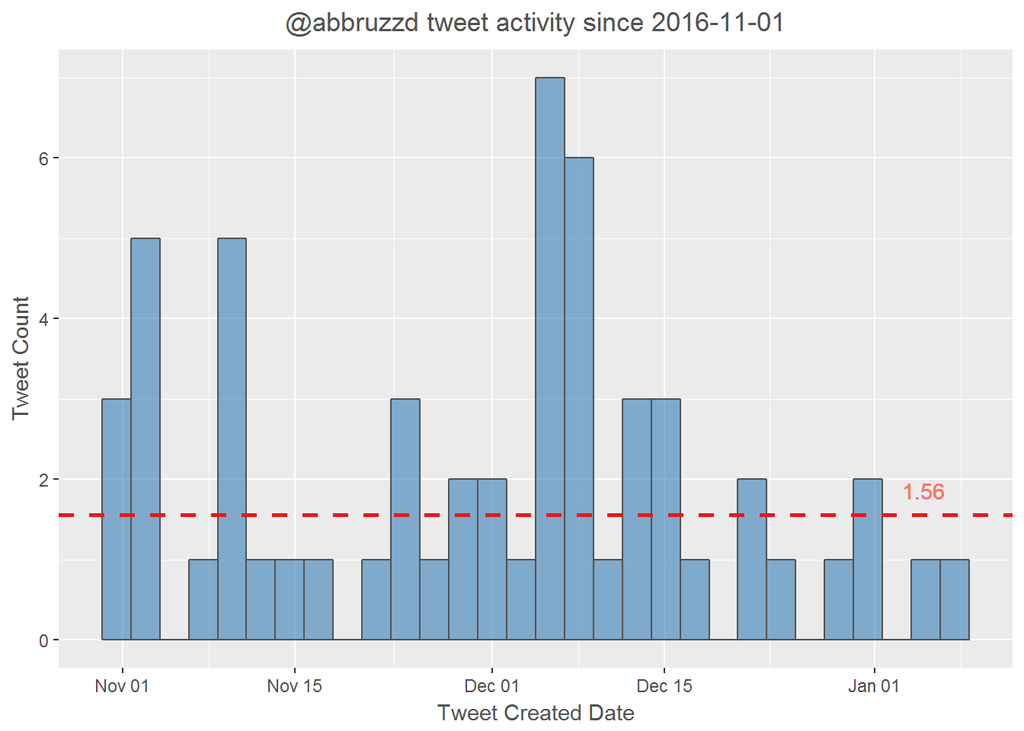

```r
# Set up the graphing colors, replacing the defaults
  cols = brewer.pal(8,"Set1")
  cols=cols[-7]

# define the create date for the graph
tw_df$create_dt <- ymd(substr(tw_df$created,0,10))
#work out the overall mean for tweeting
tw_mean <- round(mean(table(tw_df$create_dt), na.rm=TRUE),2)
# find the max date for the mean label, no bar overlap
tw_max <- max(tw_df$create_dt, na.rm=TRUE) - 3
# create the histogram graph
ggplot(data=tw_df, aes(x=create_dt)) +
  # reformat the colours
  geom_histogram(colour="grey32", fill=cols[2], alpha=0.6, na.rm = FALSE) +
  xlab("Tweet Created Date") +
  ylab("Tweet Count") +
  #addin the mean line
  geom_hline(aes(yintercept=tw_mean),
             color=cols[1], linetype="dashed", size=1, show.legend = FALSE) +
  #addin the mean label
  geom_text(aes(tw_max, (tw_mean+0.3) , label=tw_mean, colour=cols[1])) +
  #config the title
  ggtitle(paste(userName," tweet activity since ",
                min(tw_df$create_dt, na.rm=TRUE), sep="")) +
  #remove the legend, change the colour of the titles and centre the main
  theme(legend.position = "none",
        axis.title.x = element_text(colour = "grey32"),
        axis.title.y = element_text(colour = "grey32"),
        plot.title = element_text(colour = "grey32", hjust=0.5))
```

From this limited data set, what are the most [liked](https://support.twitter.com/articles/20169874) tweets?

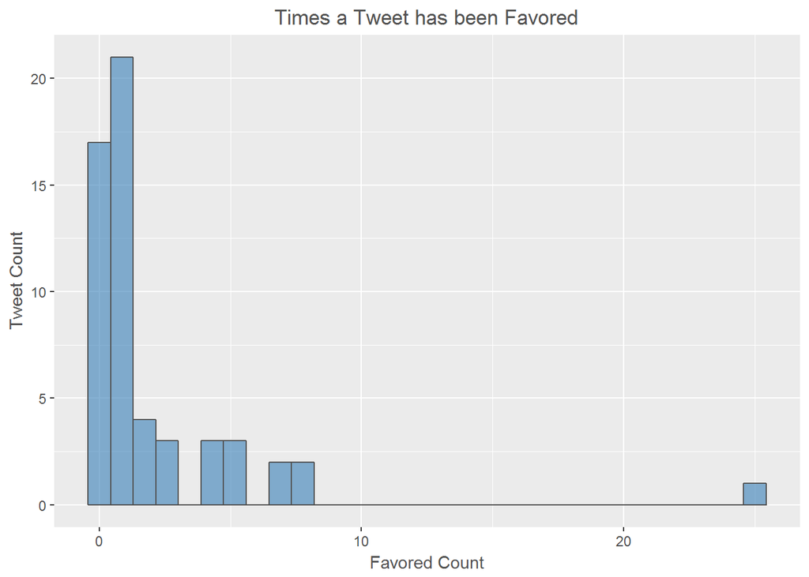

```r
#clean up the text
fav_cnt <- subset(unq_text_df, favoriteCount!="FALSE")
fav_cnt$favoriteCount <- as.numeric(fav_cnt$favoriteCount)
#graph the details
ggplot(data=fav_cnt, aes(x=favoriteCount)) +
  geom_histogram(colour="grey32", fill=cols[2], alpha=0.6, na.rm = FALSE) +
  ggtitle("Times a Tweet has been Favored") +
  ylab("Tweet Count") +
  xlab("Favored Count") +
  #remove the legend, change the colour of the titles and centre the main
  theme(legend.position = "none",
        axis.title.x = element_text(colour = "grey32"),
        axis.title.y = element_text(colour = "grey32"),
        plot.title = element_text(colour = "grey32", hjust=0.5))
```

The most Favored Tweets are:

```
+--------------------------------------------------------------+---------+
|                             text                             |  Count  |
+==============================================================+=========+
|  I loved today's visit to the @ANZ_AU Contact Centre. Great  |   25    |
|      people with a real passion for helping customers.<U+0085>      |         |
|                   https://t.co/iJTSa57Qlc                    |         |
+--------------------------------------------------------------+---------+
| A handy cheat sheet but you'll find someone with this set of |    8    |
|   skills chillin' with the unicorns and leprechauns. Let<U+0085>    |         |
|                   https://t.co/2SD1RHDXyx                    |         |
+--------------------------------------------------------------+---------+
| Great visiting Raj and the Malvern branch team today. Such a |    8    |
|        strong customer service focus! @ANZChristianV<U+0085>        |         |
|                   https://t.co/qAg4hiWBuh                    |         |
+--------------------------------------------------------------+---------+
|    Celebrating teamwork, respect and excellence @ANZ_AU;     |    7    |
|     congrats to all #takecharge winners and runners-up!<U+0085>     |         |
|                   https://t.co/iwHyhVQBbA                    |         |
+--------------------------------------------------------------+---------+
|     RBA cash rate vs underemployment rate ... amazingly      |    7    |
|    correlated. Thanks @AlanKohler https://t.co/dCzotSjJ3Y    |         |
+--------------------------------------------------------------+---------+
```

Typically Darren’s tweets are well received, being liked more often than not. The most popular tweets are ANZ focused with a very strong positive message.

What the most [re-tweeted](https://support.twitter.com/articles/77606)?

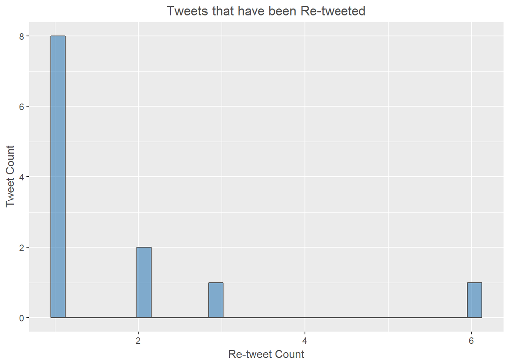

The Highest re-tweets are:

```
##
##
## +--------------------------------------------------------------+---------+
## |                             text                             |  Count  |
## +==============================================================+=========+
## |     RBA cash rate vs underemployment rate ... amazingly      |    6    |
## |    correlated. Thanks @AlanKohler https://t.co/dCzotSjJ3Y    |         |
## +--------------------------------------------------------------+---------+
## |  I loved today's visit to the @ANZ_AU Contact Centre. Great  |    3    |
## |      people with a real passion for helping customers.      |         |
## |                   https://t.co/iJTSa57Qlc                    |         |
## +--------------------------------------------------------------+---------+
## |    Celebrating teamwork, respect and excellence @ANZ_AU;     |    2    |
## |     congrats to all #takecharge winners and runners-up!     |         |
## |                   https://t.co/iwHyhVQBbA                    |         |
## +--------------------------------------------------------------+---------+
## | Great visiting Raj and the Malvern branch team today. Such a |    2    |
## |        strong customer service focus! @ANZChristianV        |         |
## |                   https://t.co/qAg4hiWBuh                    |         |
## +--------------------------------------------------------------+---------+
```

Unlike the favored items, Darren’s doesn’t experience a lot of re-tweet activity. But when it does happen, once again its largely ANZ focused with a very strong positive message.

What Topics are covered by Darren?

```
--------------------------
   Topics     Tweet_Count
------------ -------------
   #STEM.          3

   #STEM           3

   #Trump          2

#exponential       1

 #StarWars         1

  #digital         1
--------------------------
```

Asides from resent Government Education initiative [STEM](http://www.stemaustralia.edu.au/), there doesn’t seem to be any topics that regularly appear over this period.

So who is Darren talking too? The Top 10 users referenced in Darren’s tweets are;

```
-----------------------------
    People       Tweet_Count
--------------- -------------
  @ato_gov_au         3

  @AlanKohler         3

@SpirosMargaris       2

  @cgledhill          2

@MikeQuindazzi        2

    @Google           2

    @Yahoo            2

    @ANZ_AU           2

@ANZChristianV        2

@JetstarAirways       1
-----------------------------
```

Rather strangely given the most favored and re-tweeted tweets, only 2 accounts are other [ANZ’ers](https://twitter.com/search?q=%40ANZChristianV%20&src=typd&lang=en).

### *Sentiment Analysis*

What about the sentiment of what is being tweeted? First we need a clean text to work from.

```r
# define the char sets we are looking for
reg <- "([^A-Za-z_\\d#@']|'(?![A-Za-z_\\d#@]))"
# clean up the text, replacing URL, Hashtags, User, Topic references & stop words.
tidy_df <- tw_df %>% select(text) %>%
  mutate(text = str_replace_all(text,
                                #remove URLs, user & topic references
                                "https://t.co/[A-Za-z\\d]+|http://[A-Za-z\\d]+|&amp;|&lt;|&gt;|RT+|#[A-Za-z]*+|@[A-Za-z_]*",
                                "")) %>%
  unnest_tokens(word, text, token = "regex", pattern = reg) %>%
  filter(!word %in% stop_words$word,
         str_detect(word, "[a-z]"))
```

```
-----------------------------------------------
This provides a word count of 350 to work with.

-----------------------------------------------
```

Once again the limited data set isn’t helping, but we can at least start doing some Sentiment analysis.

Although it should be noted;  
* As discussed by the [tidytext](https://cran.r-project.org/web/packages/tidytext/vignettes/tidytext.html) package author [Julia Silge](http://tidytextmining.com/sentiment.html) this sentiment analysis is based on word matching which is then classified and scored. As such it loses much of the nuance of communication, especially when it comes to irony or sarcasm.  
* These methods are based upon central lexicons, [bing](https://www.cs.uic.edu/~liub/FBS/sentiment-analysis.html) and [nrc](http://saifmohammad.com/WebPages/NRC-Emotion-Lexicon.htm) which ignore Australia colloquialisms and slang usage.

With that in mind, lets have a looking using [bing](https://www.cs.uic.edu/~liub/FBS/sentiment-analysis.html).

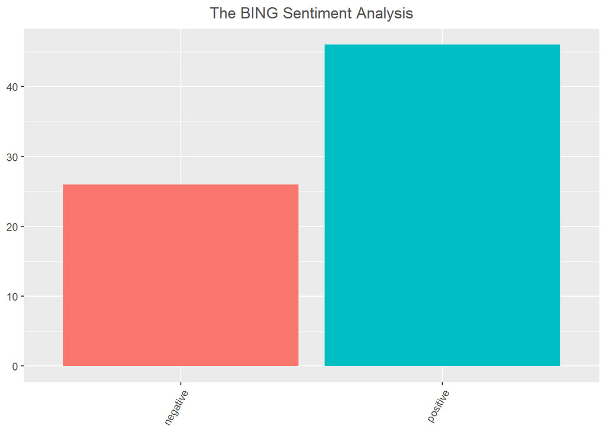

```r
# match the word listing to the bing sentiment listing
sentiment_bing <- tidy_df %>%
    inner_join(get_sentiments("bing"))
# make a data frame for graphing
  grh_bing <- as.data.frame(table(sentiment_bing$sentiment))
# graph it as bar chart
  ggplot(data = grh_bing , aes(x = Var1, y = Freq)) +
    geom_bar(aes(fill = Var1), stat = "identity") +
    theme(legend.position = "none") +
    ggtitle("The BING Sentiment Analysis") +
    theme(axis.text.x = element_text(angle = 60, hjust = 1),
          axis.title.x = element_blank(),
          axis.title.y = element_blank(),
          plot.title = element_text(colour = "grey32", hjust=0.5))
```

This presents Darren’s tweet stream as positive, which is nice.

This Analysis can be further expanding in a word cloud, displaying the strongest words classified by their sentiment.

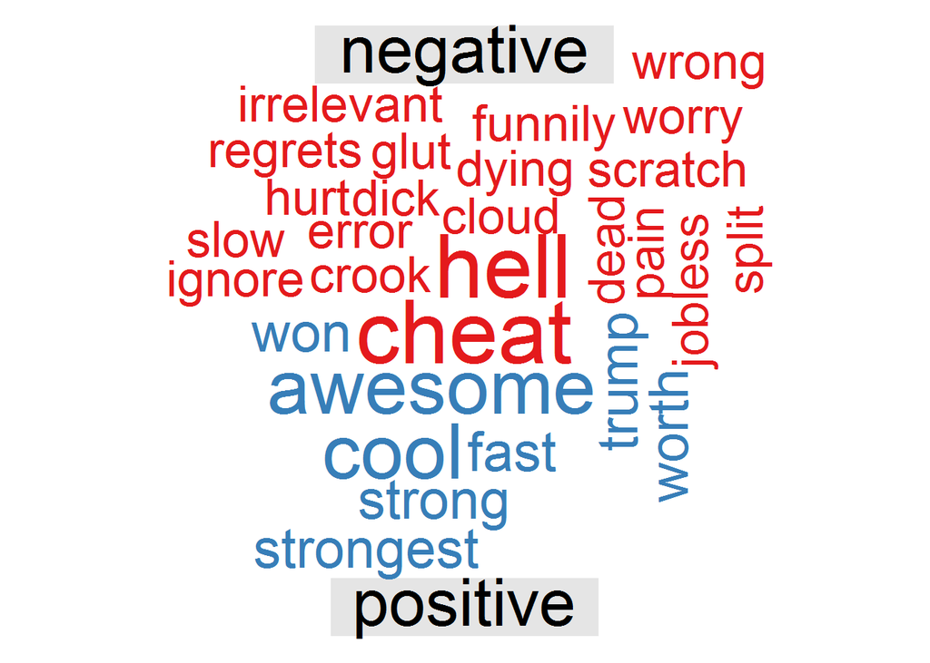

A Deeper understanding of the sentiment can be provided by [nrc](http://saifmohammad.com/WebPages/NRC-Emotion-Lexicon.htm) which goes beyond *negative vs positive* classification.

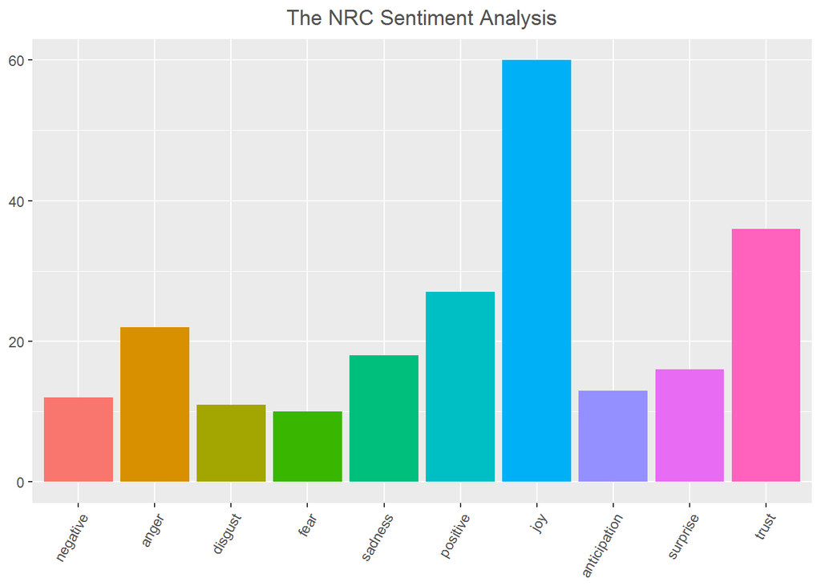

Based upon this the positive sentiments of Joy and Trust dominate Darren’s tweets.

#### *Conclusion*

So despite limited activity, Darren’s tweets are generally positive and often get liked by his network, especially when focused on ANZ.

Given this, perhaps the Microsoft facial expression API - [Emotion](https://www.microsoft.com/cognitive-services/en-us/emotion-api) using Darren’s Twitter photo is a little harsh.

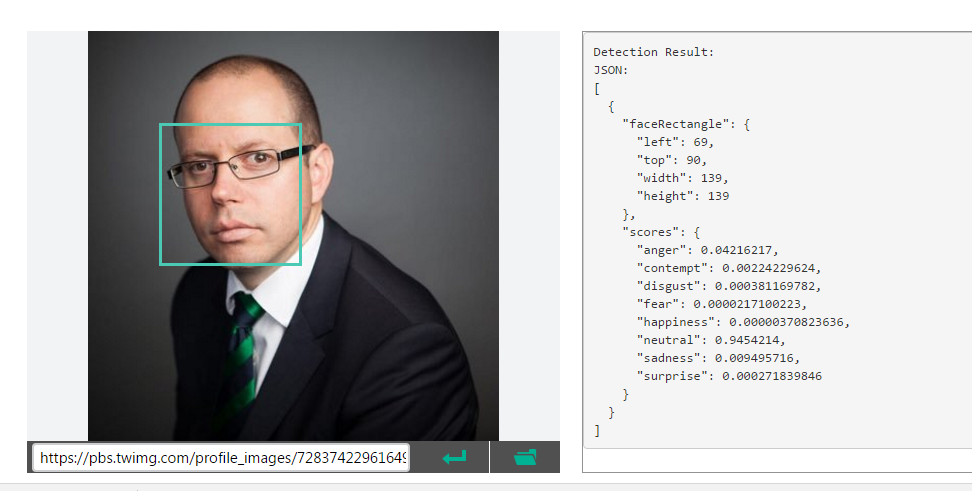

#### *References*

This Analysis has used a large number of sources, including the forever helpful [Stackoverflow](http://stackoverflow.com/).

Some of the main references are;

- The wonderful [Julia Silge](http://juliasilge.com/blog/) and her fabulous [book](http://tidytextmining.com/)
- The Twitter scrapper inspiration comes from [here](https://www.r-bloggers.com/how-to-use-r-to-scrape-tweets-super-tuesday-2016/)
- The MS API Inspiration follows from [here](https://www.r-bloggers.com/election-2016-tracking-emotions-with-r-and-python/)

**– end of document –**